# A Survival Model in Stan_with comments by Tiago

# Posterior predictive checks

Posterior predictive checks constitute a family of powerful methods to scrutinize relevant aspects of your model.

See the excellent bayesplot vignette [Graphical posterior predictive checks using the bayesplot package](https://cran.r-project.org/web/packages/bayesplot/vignettes/graphical-ppcs.html) for an introdution and practical instructions.

Below we run various posteriod predictive checks constrained to the instances (individuals) that came with non-censored survival times:

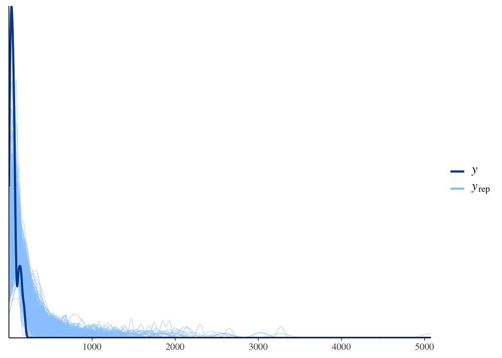

```r
surv_times_rep <- as.matrix(post[,1,sprintf("times_censored_sampled[%d]", 1:stan_data$N_uncensored)])
surv_times_train <- times[!msk_censored]
###########################################################################################
color_scheme_set("brightblue")
ppc_dens_overlay(surv_times_train, surv_times_rep[1:500,])
```

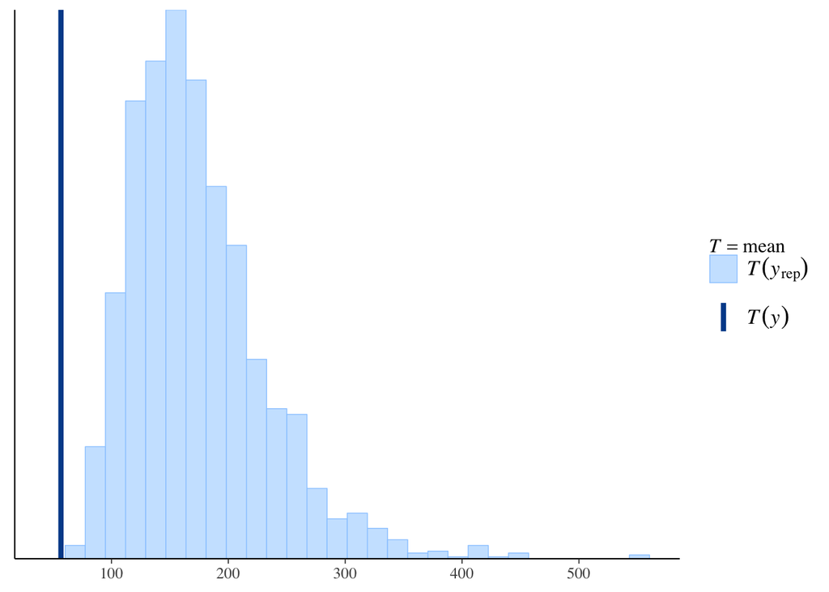

```r
ppc_stat(surv_times_train, surv_times_rep, stat = "mean")
```

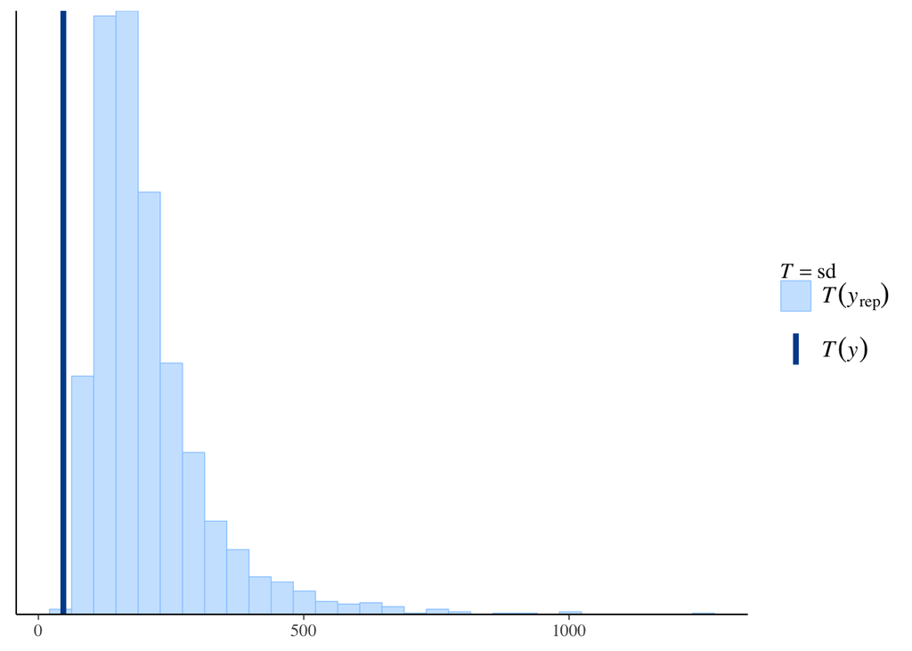

```r
ppc_stat(surv_times_train, surv_times_rep, stat = "sd")
```

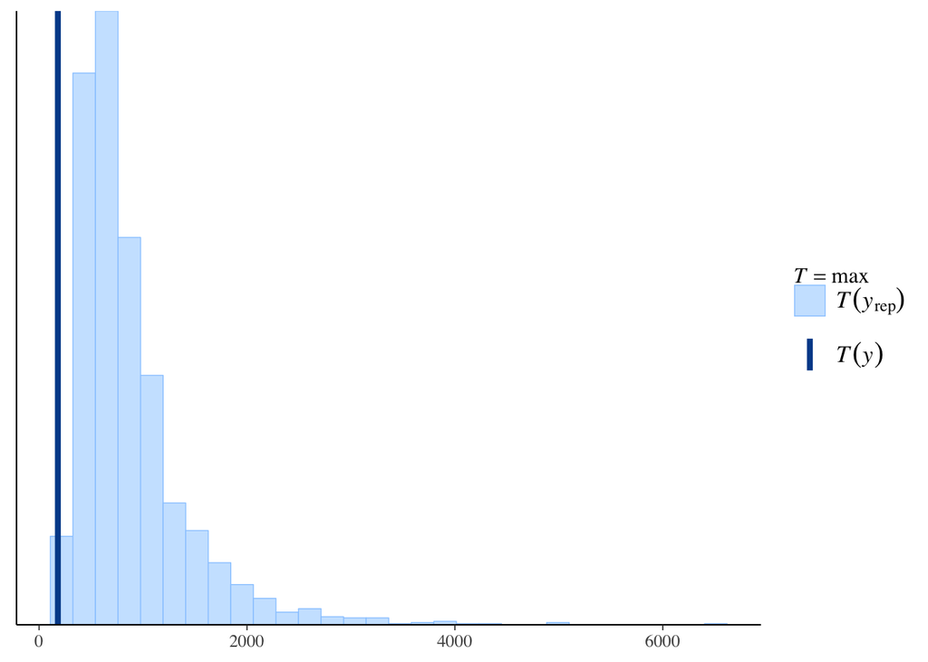

```r
ppc_stat(surv_times_train, surv_times_rep, stat = "max")
```

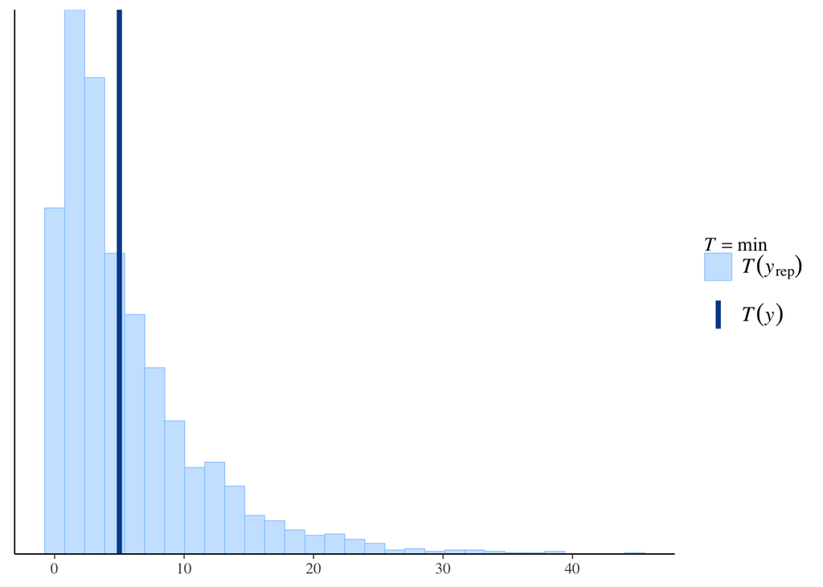

```r
ppc_stat(surv_times_train, surv_times_rep, stat = "min")
```

As it turns out our model essentially suffers from overdispersion and a tendency for too large survival times. Potential ways to improve this, would be to consider accelerated failure time models, semiparametric base-line hazards or more general parametric survival models, like the Royston & Parmar based family of models.

[Flexible parametric proportional-hazards and proportional-odds models for censored survival data, with application to prognostic modelling and estimation of treatment effects.](https://www.ncbi.nlm.nih.gov/pubmed/12210632). A related case study will follow soon.

**TC:** Maybe you could add a small conclusion about what does the model allow you to say regarding the survival time of an individual given the covariates you include in the model. And then follow with the overdispersion issues you just mention and suggestions for improvement.

## Generated Quantities Block

**TC:** I would move this part to the section where you explain the other model blocks above.

The careful reader probably noticed that we did not specify how to obtain the parameter vector `times_censored_sampled` required for the posterior predictive checks. This can be achieved by appending the `generated quantities` block below to our Stan model:

```
generated quantities {
    vector[N_uncensored] times_censored_sampled;
    for(i in 1:N_uncensored) {
        times_censored_sampled[i] = exponential_rng(exp(intercept+X_uncensored[i,]*betas));
    }
}
```